# Lab 6

Hunter Finger

March 28, 2019

# Instructions

**Exercises:** 4 (Pg. 302); 1 (Pgs. 316-317); 1 (Pgs. 328-329); 1, 2 (Pgs. 353-354)

**Assigned:** Friday, March 22, 2019

**Due:** Friday, March 29, 2019 by 5:00 PM

**Submission:** Submit via an electronic document on Sakai. Must be submitted as a HTML file generated in RStudio. All assigned problems are chosen according to the textbook *R for Data Science*. You do not need R code to answer every question. If you answer without using R code, delete the code chunk. If the question requires R code, make sure you display R code. If the question requires a figure, make sure you display a figure. A lot of the questions can be answered in written response, but require R code and/or figures for understanding and explaining.

# Chapter 16 (Pg. 302)

## Exercise 4

### a)

```r
last_value = function(x){
    x[[length(x)]]
}
last_value(1:8)
```

```
## [1] 8
```

```r
last_value(1)
```

```
## [1] 1
```

This function uses the double brackets to extract a single value.

### b)

```r
even_pos = function(x){
    x[seq_along(x) %% 2 == 0]
}

even_pos(1:13)
```

```
## [1]  2  4  6  8 10 12
```

### c)

```r
except_last = function(x){
  x[1:length(x)-1]
}

except_last(1:5)
```

```
## [1] 1 2 3 4
```

```r
except_last(1)
```

```
## numeric(0)
```

### d)

```r
even_num = function(x){
  x[x %% 2 == 0]
}

even_num(8:13)
```

```
## [1]  8 10 12
```

# Chapter 17 (Pgs. 316-317)

## Exercise 1

### a)

```r
answer <- vector("double", ncol(mtcars))
names(answer) = names(mtcars)
for (i in names(mtcars)){
  answer[i] = mean(mtcars[[i]])
}
answer
```

```
##        mpg        cyl       disp         hp       drat         wt
##  20.090625   6.187500 230.721875 146.687500   3.596563   3.217250
##       qsec         vs         am       gear       carb
##  17.848750   0.437500   0.406250   3.687500   2.812500
```

### b)

```r
answer = vector("list", ncol(nycflights13::flights))
names(answer) = names(nycflights13::flights)
for (i in names(nycflights13::flights)){
  answer[i] = class(nycflights13::flights[[i]])
}
answer
```

```
## $year
## [1] "integer"
##
## $month
## [1] "integer"
##
## $day
## [1] "integer"
##
## $dep_time
## [1] "integer"
##
## $sched_dep_time
## [1] "integer"
##
## $dep_delay
## [1] "numeric"
##
## $arr_time
## [1] "integer"
##
## $sched_arr_time
## [1] "integer"
##
## $arr_delay
## [1] "numeric"
##
## $carrier
## [1] "character"
##
## $flight
## [1] "integer"
##
## $tailnum
## [1] "character"
##
## $origin
## [1] "character"
##
## $dest
## [1] "character"
##
## $air_time
## [1] "numeric"
##
## $distance
## [1] "numeric"
##
## $hour
## [1] "numeric"
##
## $minute
## [1] "numeric"
##
## $time_hour
## [1] "POSIXct"
```

### c)

```r
answer = vector("double", ncol(iris))
names(answer) = names(iris)
for(i in names(iris)){
  answer[i] = length(unique(iris[[i]]))
}
answer
```

```
## Sepal.Length  Sepal.Width Petal.Length  Petal.Width      Species
##           35           23           43           22            3
```

### d)

```r
n <- 10
av <- c(-10, 0, 10, 100)
normals <- vector("list", length(av))
for (i in seq_along(normals)) {
  normals[[i]] <- rnorm(n, mean = av[i])
}
normals
```

```
## [[1]]
##  [1]  -7.290851  -7.764324  -9.242418  -9.741126 -10.210362 -10.362599
##  [7] -10.918733 -10.612019  -9.660664 -10.718178
##
## [[2]]
##  [1]  0.21209980 -0.73121324  1.05840437 -2.71107541 -0.06380500
##  [6] -0.63491154  0.92819918 -1.35217889 -0.07283304  0.66884722
##
## [[3]]
##  [1] 10.730438  8.399597 10.196142  9.027032 10.607041 12.007113 10.517228
##  [8] 10.097165 10.778538 10.090828
##
## [[4]]
##  [1] 101.13557 100.20411 100.08811 100.43892  98.51337  99.90106  99.44373
##  [8]  99.27412 102.18793 100.84827
```

# Chapter 17 (Pgs. 328-329)

## Exercise 1

### a)

```r
map_dbl(mtcars, mean)
```

```
##        mpg        cyl       disp         hp       drat         wt
##  20.090625   6.187500 230.721875 146.687500   3.596563   3.217250
##       qsec         vs         am       gear       carb
##  17.848750   0.437500   0.406250   3.687500   2.812500
```

### b)

```r
map_chr(nycflights13::flights, typeof)
```

```
##           year          month            day       dep_time sched_dep_time
##      "integer"      "integer"      "integer"      "integer"      "integer"
##      dep_delay       arr_time sched_arr_time      arr_delay        carrier
##       "double"      "integer"      "integer"       "double"    "character"
##         flight        tailnum         origin           dest       air_time
##      "integer"    "character"    "character"    "character"       "double"
##       distance           hour         minute      time_hour
##       "double"       "double"       "double"       "double"
```

### c)

```r
map_int(iris, function(x) length(unique(x)))
```

```
## Sepal.Length  Sepal.Width Petal.Length  Petal.Width      Species
##           35           23           43           22            3
```

### d)

```r
map(c(-10, 0, 10, 100), ~ rnorm(n = 10, mean = .))
```

```
## [[1]]
##  [1]  -9.790256 -11.085792 -10.605952  -9.359794  -9.320261  -9.603004
##  [7] -12.936392  -9.997531 -10.656941  -9.908541
##
## [[2]]
##  [1]  0.2736322  0.3899316 -0.4532101  1.3793891 -0.6736414 -0.7498645
##  [7] -0.6988946  1.5521774  0.6944301 -0.1072486
##
## [[3]]
##  [1] 11.233842 10.056815  8.869551 10.647374 10.562280  9.417173  9.562819
##  [8]  9.357622  9.591467 10.199329
##
## [[4]]
##  [1]  99.18719  99.98988 100.44551  99.40079  99.32641  99.68864  99.71842
##  [8] 100.62607 100.58864  99.47627
```

# Chapter 18 (Pgs. 353-354)

## Exercise 1

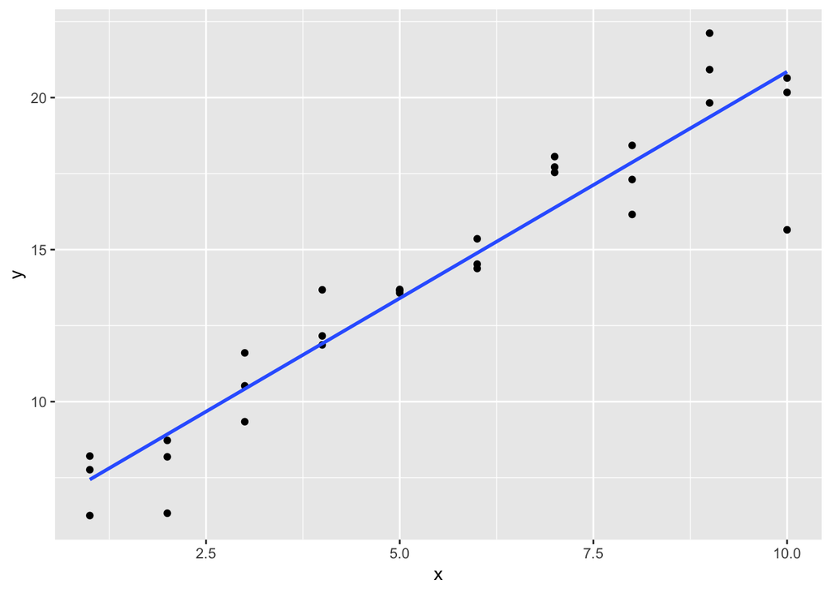

```r
sim1a <- tibble(x = rep(1:10, each = 3), y=x*1.5+6+rt(length(x),df=2))
ggplot(sim1a, aes(x=x,y=y)) + geom_point() + geom_smooth(method = "lm", se = F)
```

## Exercise 2

```r
measure_distance <- function(mod, data) {
  diff <- data$y - make_prediction(mod, data)
  mean(abs(diff))
}

make_prediction <- function(mod, data){
  mod[1] + mod[2] * data$x
}

model <- optim(c(0,0), measure_distance, data = sim1a)
model
```

```
## $par
## [1] 5.867449 1.550904
##
## $value
## [1] 0.9780822
##
## $counts
## function gradient
##      129       NA
##
## $convergence
## [1] 0
##
## $message
## NULL
```

The slope and y intercept are very close to what you see in exercise 1 of this chapter. Optim is essentially doing the same thing that the linear model did with similar results.